# Vignette of rGMAP package

Wenbao Yu

rGMAP version 1.3.1 Updated on 2018-08-23

# 1 Introduction

- rGMAP is an R package for implementing GMAP algorithm for detecting topologically associating domains (TADs) and sub-domains (sub-TADs)
- The detailed of the algorithm can be found in *Yu, W., He, B., & Tan, K. (2017). Identifying topologically associating domains and subdomains by Gaussian Mixture model And Proportion test. Nature Communications, 8, 535*

# 2 Update for this version

- The HiC contact matrix *hic_mat* could either be a data.frame/matrix or a tab/space delimited text file
- Support multiple chromosomes if index file *index_file* was also provided. The *index_file* and *hic_mat* are compatible to output of HiC-Pro
- If the input hic_mat is just from a sigle chromosome and no index_file was provided: the first two columns should be the i_th, j_th bin of the chromosome if hic_mat is in 3-column format (**i j count**)
- n by n matrix of hic_mat is still supported, where n is the total number of bins of a hic contact map for a single chromosome

# 3 Installation

## 3.1 Install from Github

```r
library(devtools)
install_github('wbaopaul/rGMAP')
```

## 3.2 Install from source codes

```r
install.packages('path to rGMAP_1.3.1.tar.gz', repos = NULL, type = 'source')
```

# 4 Examples

## 4.1 Work on an published Hi-C data

> Data from *Rao et al., Cell 2014, A 3D map of the human genome at kilobase resolution reveals principles of chromatin looping*

> KR normalized Hi-C data for IMR90 cell line, on chr15 with resolution 10kb

```r
library(rGMAP)
hic_rao_IMR90_chr15
```

```
#>             n1    n2        count
#>       1:  2001  2001 1594.4993397
#>       2:  2001  2002  173.5189748
#>       3:  2002  2002 2012.2132432
#>       4:  2001  2003    7.1718521
#>       5:  2002  2003    6.0486110
#>      ---
#> 3553174: 10237 10250    0.8934246
#> 3553175:  9729 10251    1.0049196
#> 3553176:  9861 10251    1.9337094
#> 3553177: 10005 10251    0.8993636
#> 3553178: 10237 10251    0.8934246
```

```r
res = rGMAP(hic_rao_IMR90_chr15, resl = 10 * 1000, dom_order = 2)
names(res)
```

```
#> [1] "tads"     "hierTads" "params"
```

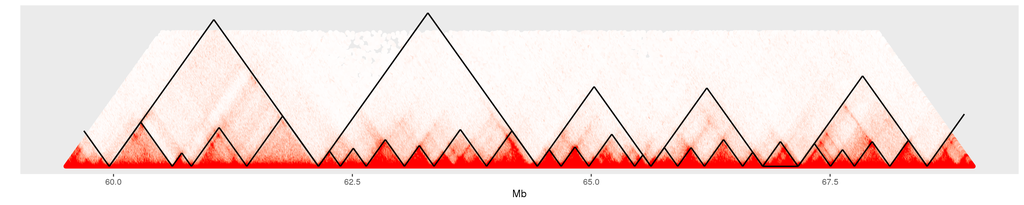

```r
#quickly visualize some hierarchical domains
pp = plotdom(hic_rao_IMR90_chr15, res$hierTads, 5950, 6900, 30, 10000)
pp$p2
```

## 4.2 Compatible with HiC-Pro output matrix and index file

- The format of the index file (10kb for example):

```
chr1  0 10000   1
chr1    10000   20000   2
chr1    20000   30000   3
chr1    30000   40000   4
......
```

- The format of the hic_mat data:

```
10  127 10.372577
10  188 4.161271
10  281 36.072713
17  5822    2.418056
......
```

## 4.3 Work on an simulated example

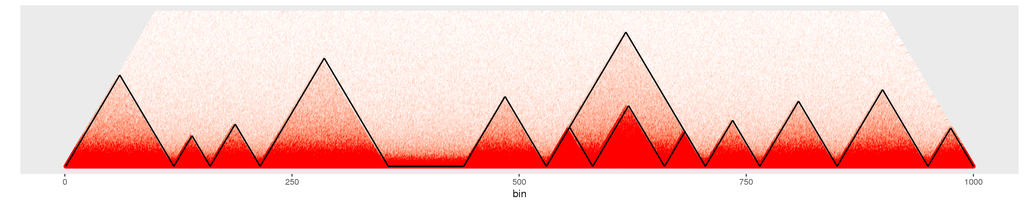

```r
set.seed(1)
simu_res = data_simu('poisson-dist-hier')
true_domains = simu_res$hierTads
simu_mat = simu_res$hic_mat
predicted_domains = rGMAP(simu_mat, resl = 1)$hierTads

pp = plotdom(simu_mat, predicted_domains, 1, 1000, 20, 1)
pp$p2
```

```r
#true_domains
#predicted_domains
```

[output not shown]

[output cut: 21 more lines]

[output not shown]